# Inital data analysis for FINDONOR- CHANGES IN SELF-RATED HEALTH DURING THE STUDY AND IT’S RELATION TO IRON BIOMARKERS

## freq_energy, freq_sad, health_soc, freq_calm, accomplish

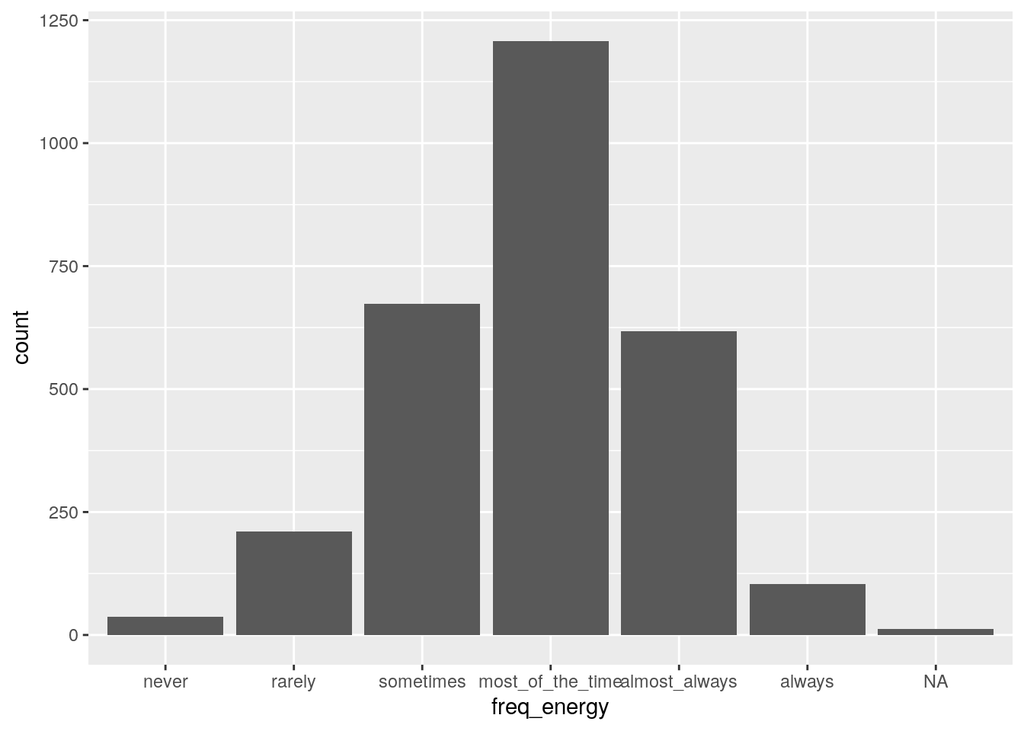

```r
ggplot(data) + geom_bar(aes(x=freq_energy))
```

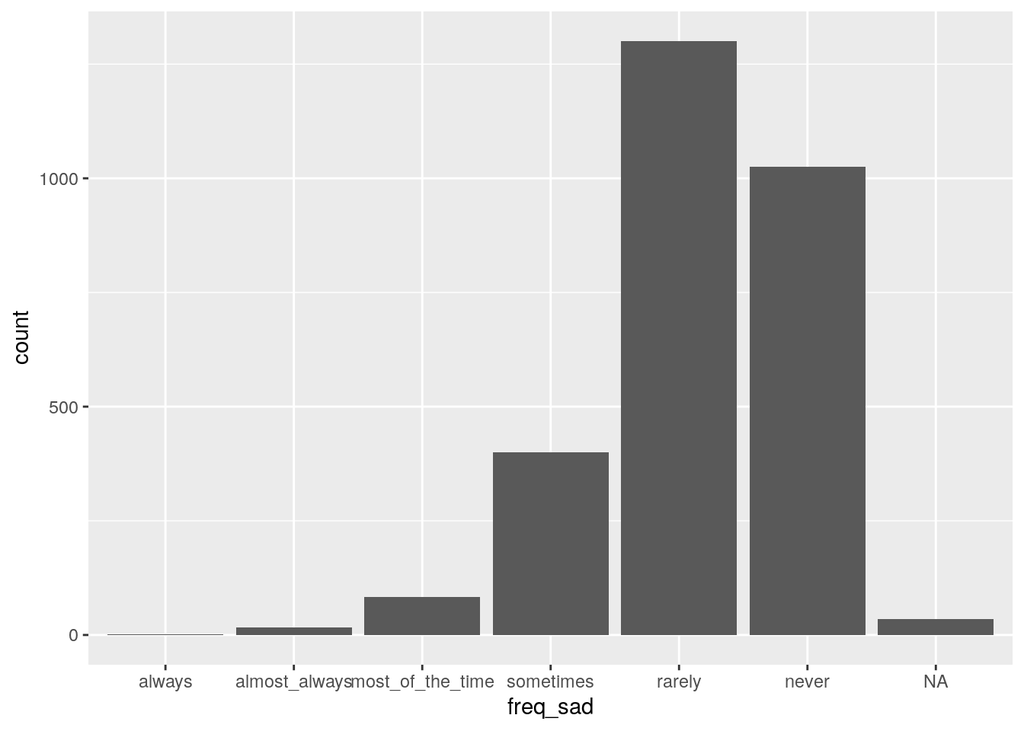

```r
ggplot(data) + geom_bar(aes(x=freq_sad))
```

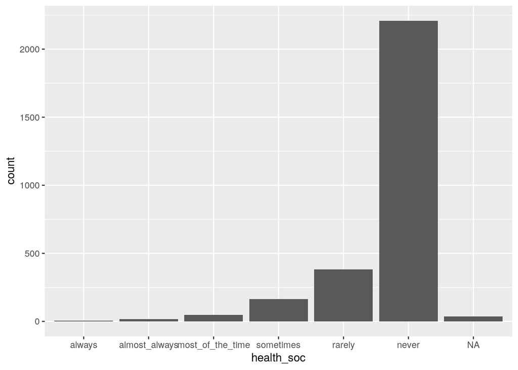

```r
ggplot(data) + geom_bar(aes(x=health_soc))
```

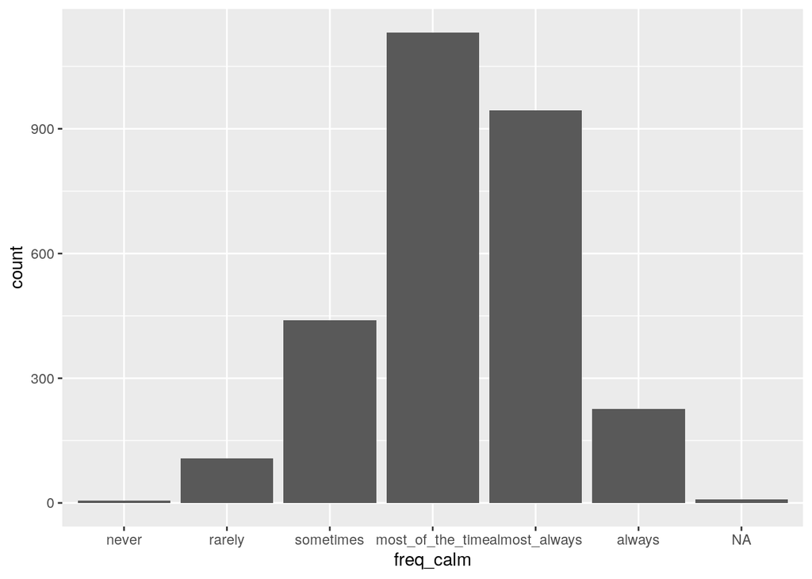

```r
ggplot(data) + geom_bar(aes(x=freq_calm))
```

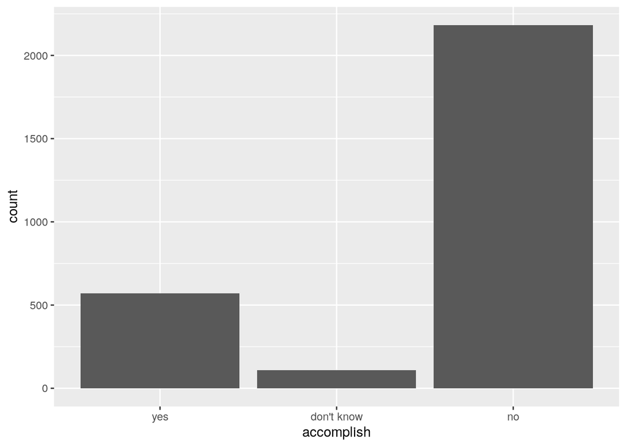

```r
ggplot(data) + geom_bar(aes(x=accomplish))
```

```r
table(is.na(data$freq_energy))
```

```
##
## FALSE  TRUE
##  2850    12
```

```r
table(is.na(data$freq_sad))
```

```
##
## FALSE  TRUE
##  2827    35
```

```r
table(is.na(data$health_soc))
```

```
##
## FALSE  TRUE
##  2826    36
```

```r
table(is.na(data$freq_calm))
```

```
##
## FALSE  TRUE
##  2854     8
```

```r
table(is.na(data$accomplish))
```

```
##
## FALSE
##  2862
```

accomplish has a tricky distribution.

freq_energy correlates with phys_cond and can be dropped for that.

health_soc has a very skewed distiribution.

## h_act_light vs h_act_noen

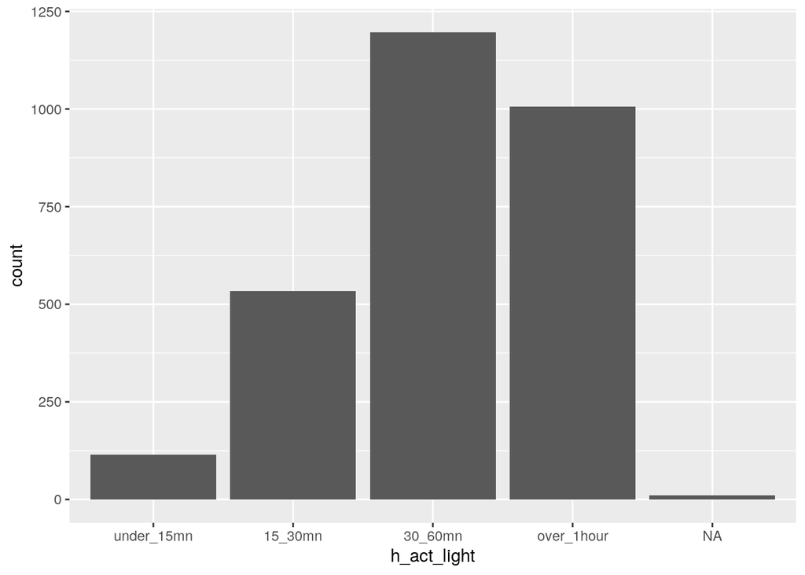

```r
ggplot(data) + geom_bar(aes(x=h_act_light))
```

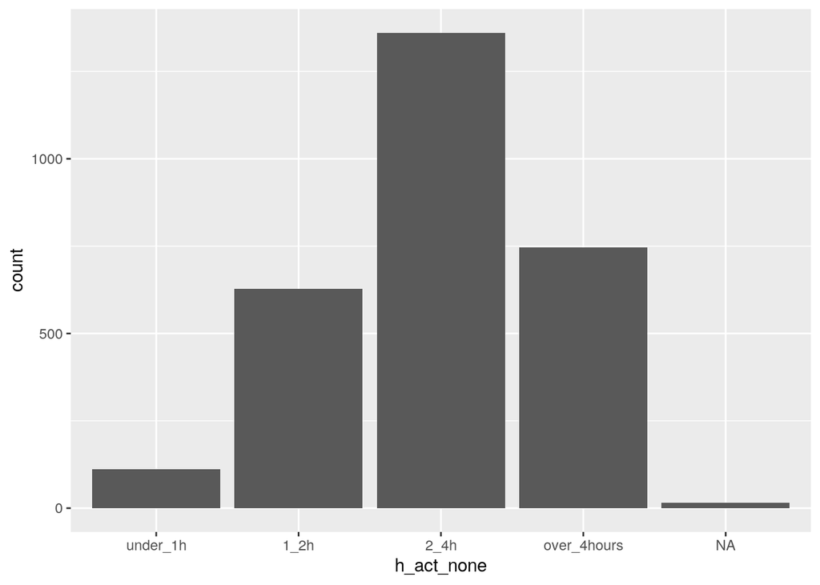

```r
ggplot(data) + geom_bar(aes(x=h_act_none))
```

```r
table(is.na(data$h_act_light))
```

```
##
## FALSE  TRUE
##  2851    11
```

```r
table(is.na(data$h_act_none))
```

```
##
## FALSE  TRUE
##  2847    15
```

h_act_light looses less data.

# Drop questions based on correlation analysis

Based on the above we have decided to drop: act_light, health_c, vita_C, sleep_24h, freq_vege, freq_sports, freq_spirits, freq_beer, freq_wine, freq_cutlets, diet, freq_fish, freq_eggs, weight, height, accomplish, freq_energy, health_soc, freq_sad, h_act_none

```r
temp <- data %>% dplyr::select(-iron_supp_detailed, -life_qual, -education, -employment,-AgeGroup, -SixMonthsFromStartCount_FB,-TwoYearsFromStartCount_FB, -act_light, -health_c, -vita_C, -sleep_24h, -freq_vege, -freq_sports, -freq_spirits, -freq_wine, -freq_beer, -freq_cutlets, -diet, -freq_fish, -freq_eggs, -weight, -height, -accomplish, -freq_energy, -health_soc, -freq_sad,-h_act_none)

#Later in explorative_analysis.Rmd we find out that some variables cannot be fitted. We remove them now not to loose data over them
temp <- temp %>% dplyr::select(-sleep_night,
-ment_inf,
-vita_iron
#education is removed later as it was only asked in the second questionaire
#smoking_behavior # this is brought in and removed in
)

temp <- na.omit(temp)
temp %>% group_by(questionnaire) %>% count()
```

```
## # A tibble: 2 x 2
## # Groups:   questionnaire [2]
##   questionnaire     n
##   <chr>         <int>
## 1 First          1186
## 2 Second         1245
```

From 33 questions.

```r
#But questionnaire, donor, group, age, sex and date are not procesed into change between questionnaires
tx <- setdiff(colnames(temp),c("questionnaire", "donor", "group", "age", "sex","date" ))
tx
```

```
##  [1] "act_heavy"     "phys_inf"      "freq_calm"     "sleep_enough"
##  [5] "sleep_tired"   "freq_red_meat" "freq_fruits"   "freq_juices"
##  [9] "freq_wholem"   "freq_milk"     "freq_cof"      "freq_tea"
## [13] "smoking"       "phys_cond"     "day_act"       "h_act_light"
## [17] "cholesterol"   "blood_sugar"   "HBP"           "low_hb_hist"
## [21] "anemia_hist"   "high_hb_hist"  "anti_inf"      "vita_multi"
## [25] "iron_supp"     "BMI"           "freq_alc"
```

```r
length(tx)
```

```
## [1] 27
```

How will the sex/menopause groups look

```r
temp %>% group_by(questionnaire,group) %>% filter(group != 'Women_pre_menop_no_mens') %>%  count()
```

```
## # A tibble: 6 x 3
## # Groups:   questionnaire, group [6]
##   questionnaire group                    n
##   <chr>         <fct>                <int>
## 1 First         Men                    492
## 2 First         Post_menopause_women   280
## 3 First         Pre_menopause_women    414
## 4 Second        Men                    509
## 5 Second        Post_menopause_women   307
## 6 Second        Pre_menopause_women    429
```

```r
table(table(temp$donor))
```

```
##
##    1    2
##  337 1047
```

1047 donors with complete data in both questionaires.

By excluding several questions that correlate with other questions and have distributions that are skewed (e.g. diet, accomplish) or are uniformative (e.g. act_light) or are not clearly ordered factors (like diet) we get complete data for about two hundred more persons. There might still be too many explenatory variables for the smallest group i.e. Post_menopause_women and we will still loose data when we look for complete cases in both questionaires.

# Recode answers as change between the questionnaires

Exclude questions that are dealt with later in the regression data processing: BMI, smoking health, date, age, group. “health” has been already excluded. N.B. smoking is not part of the hypothesis testing. It is just processed later.

```r
temp <- temp %>% dplyr::select(-BMI,-smoking,-date,-age,-group,-sex)
#Extract complete data for both questinaires and separate questionaire answers into different columns for processing
splitbyq <- split(temp,f=temp$questionnaire)
first <- splitbyq[["First"]]
second <- splitbyq[["Second"]]
colnames(second) <- paste0(colnames(second),"_2")
temp <- inner_join(first,second,by=c("donor"="donor_2"))
cat(nrow(temp),"complete cases in both questionnaires\n")
```

```
## 1047 complete cases in both questionnaires
```

```r
classes <- sort(unlist(lapply(lapply(first,class),paste,collapse=" ")))
classes <- as.tibble(cbind(names(classes),classes))
no_answers <- first %>% summarise_all(~length(levels(.)))
no_answers <- as_tibble(cbind(variable = names(no_answers), t(no_answers)))
no_answers <- full_join(no_answers,classes,by=c("variable"="V1")) %>% rename(no_answers=V2)
no_answers %>% group_by(no_answers)  %>% count() %>%  arrange(n)
```

```
## # A tibble: 5 x 2
## # Groups:   no_answers [5]
##   no_answers     n
##   <chr>      <int>
## 1 3              1
## 2 5              1
## 3 4              7
## 4 0              9
## 5 6              9
```

```r
no_answers %>%  filter(no_answers == 0)
```

```
## # A tibble: 9 x 3
##   variable      no_answers classes
##   <chr>         <chr>      <chr>
## 1 donor         0          character
## 2 cholesterol   0          logical
## 3 blood_sugar   0          logical
## 4 HBP           0          logical
## 5 low_hb_hist   0          logical
## 6 anemia_hist   0          logical
## 7 high_hb_hist  0          logical
## 8 iron_supp     0          logical
## 9 questionnaire 0          character
```

no_aswers == 0 are non-factoral variables. Change in cholesterol, blood_sugar, HBP, low_hb_hist, anemia_hist, high_hb_hist is coded as if the status changed during the study.

```r
temp <- temp %>% mutate(cholesterol_d = case_when(cholesterol == 0 & cholesterol_2 == 1 ~ 1,
                                          TRUE ~ 0
                                          )) %>% mutate(cholesterol_d = as.logical(cholesterol_d))

temp <- temp %>% mutate(blood_sugar_d = case_when(blood_sugar == 0 & blood_sugar_2 == 1 ~ 1,
                                          TRUE ~ 0
                                          )) %>% mutate(blood_sugar_d = as.logical(blood_sugar_d))

temp <- temp %>% mutate(HBP_d = case_when(HBP == 0 & HBP_2 == 1 ~ 1,
                                          TRUE ~ 0
                                          )) %>% mutate(HBP_d = as.logical(HBP_d))

temp <- temp %>% mutate(low_hb_hist_d = case_when(low_hb_hist == 0 & low_hb_hist_2 == 1 ~ 1,
                                          TRUE ~ 0
                                          )) %>% mutate(low_hb_hist_d = as.logical(low_hb_hist_d))

temp <- temp %>% mutate(anemia_hist_d = case_when(anemia_hist == 0 & anemia_hist_2 == 1 ~ 1,
                                          TRUE ~ 0
                                          )) %>% mutate(anemia_hist_d = as.logical(anemia_hist_d))

temp <- temp %>% mutate(high_hb_hist_d = case_when(high_hb_hist == 0 & high_hb_hist_2 == 1 ~ 1,
                                          TRUE ~ 0
                                          )) %>% mutate(high_hb_hist_d = as.logical(high_hb_hist_d))
```

iron_supp recoded as either reducing, stable or increasing.

```r
temp <- temp %>% mutate(iron_supp_d = case_when(iron_supp == FALSE & iron_supp_2 == TRUE ~ "Increased",
                                                iron_supp == TRUE & iron_supp_2 == FALSE ~ "Decreased",
                                          TRUE ~ "Stable"
                                          )) %>% mutate( iron_supp_d= factor(iron_supp_d,levels = c("Decreased","Stable","Increased"),ordered = TRUE))
```

sleep_night recoded as difference

```r
##Later in explorative_analysis.Rmd we find out that some variables cannot be fitted. We remove them now not to loose data over them
#temp <- temp %>% mutate(sleep_night_d = sleep_night_2 - sleep_night)
```

```r
no_answers %>%  filter(no_answers == 6)
```

```
## # A tibble: 9 x 3
##   variable      no_answers classes
##   <chr>         <chr>      <chr>
## 1 freq_calm     6          ordered factor
## 2 freq_red_meat 6          ordered factor
## 3 freq_fruits   6          ordered factor
## 4 freq_juices   6          ordered factor
## 5 freq_wholem   6          ordered factor
## 6 freq_milk     6          ordered factor
## 7 freq_cof      6          ordered factor
## 8 freq_tea      6          ordered factor
## 9 phys_cond     6          ordered factor
```

These are all ordered factors. They are recoded as either reducing, stable or increasing.

```r
temp <- temp %>% mutate(freq_calm_d = as.numeric(freq_calm_2)  - as.numeric(freq_calm)) %>%
  mutate(freq_calm_d = case_when(
    freq_calm_d > 0 ~ "Increased",
    freq_calm_d < 0 ~ "Decreased",
    TRUE ~ "Stable"
  )) %>% mutate( freq_calm_d= factor(freq_calm_d,levels = c("Decreased","Stable","Increased"),ordered = TRUE))

temp <- temp %>% mutate(freq_red_meat_d = as.numeric(freq_red_meat_2)  - as.numeric(freq_red_meat)) %>%
  mutate(freq_red_meat_d = case_when(
    freq_red_meat_d > 0 ~ "Increased",
    freq_red_meat_d < 0 ~ "Decreased",
    TRUE ~ "Stable"
  )) %>% mutate( freq_red_meat_d= factor(freq_red_meat_d,levels = c("Decreased","Stable","Increased"),ordered = TRUE))

temp <- temp %>% mutate(freq_fruits_d = as.numeric(freq_fruits_2)  - as.numeric(freq_fruits)) %>%
  mutate(freq_fruits_d = case_when(
    freq_fruits_d > 0 ~ "Increased",
    freq_fruits_d < 0 ~ "Decreased",
    TRUE ~ "Stable"
  )) %>% mutate( freq_fruits_d= factor(freq_fruits_d,levels = c("Decreased","Stable","Increased"),ordered = TRUE))

temp <- temp %>% mutate(freq_juices_d = as.numeric(freq_juices_2)  - as.numeric(freq_juices)) %>%
  mutate(freq_juices_d = case_when(
    freq_juices_d > 0 ~ "Increased",
    freq_juices_d < 0 ~ "Decreased",
    TRUE ~ "Stable"
  )) %>% mutate( freq_juices_d= factor(freq_juices_d,levels = c("Decreased","Stable","Increased"),ordered = TRUE))

temp <- temp %>% mutate(freq_wholem_d = as.numeric(freq_wholem_2)  - as.numeric(freq_wholem)) %>%
  mutate(freq_wholem_d = case_when(
    freq_wholem_d > 0 ~ "Increased",
    freq_wholem_d < 0 ~ "Decreased",
    TRUE ~ "Stable"
  )) %>% mutate( freq_wholem_d= factor(freq_wholem_d,levels = c("Decreased","Stable","Increased"),ordered = TRUE))

temp <- temp %>% mutate(freq_milk_d = as.numeric(freq_milk_2)  - as.numeric(freq_milk)) %>%
  mutate(freq_milk_d = case_when(
    freq_milk_d > 0 ~ "Increased",
    freq_milk_d < 0 ~ "Decreased",
    TRUE ~ "Stable"
  )) %>% mutate( freq_milk_d= factor(freq_milk_d,levels = c("Decreased","Stable","Increased"),ordered = TRUE))

temp <- temp %>% mutate(freq_cof_d = as.numeric(freq_cof_2)  - as.numeric(freq_cof)) %>%
  mutate(freq_cof_d = case_when(
    freq_cof_d > 0 ~ "Increased",
    freq_cof_d < 0 ~ "Decreased",
    TRUE ~ "Stable"
  )) %>% mutate( freq_cof_d= factor(freq_cof_d,levels = c("Decreased","Stable","Increased"),ordered = TRUE))

temp <- temp %>% mutate(freq_tea_d = as.numeric(freq_tea_2)  - as.numeric(freq_tea)) %>%
  mutate(freq_tea_d = case_when(
    freq_tea_d > 0 ~ "Increased",
    freq_tea_d < 0 ~ "Decreased",
    TRUE ~ "Stable"
  )) %>% mutate( freq_tea_d= factor(freq_tea_d,levels = c("Decreased","Stable","Increased"),ordered = TRUE))

temp <- temp %>% mutate(phys_cond_d = as.numeric(phys_cond_2)  - as.numeric(phys_cond)) %>%
  mutate(phys_cond_d = case_when(
    phys_cond_d > 0 ~ "Increased",
    phys_cond_d < 0 ~ "Decreased",
    TRUE ~ "Stable"
  )) %>% mutate( phys_cond_d= factor(phys_cond_d,levels = c("Decreased","Stable","Increased"),ordered = TRUE))
```

```r
no_answers %>%  filter(no_answers == 4)
```

```
## # A tibble: 7 x 3
##   variable     no_answers classes
##   <chr>        <chr>      <chr>
## 1 act_heavy    4          ordered factor
## 2 sleep_enough 4          ordered factor
## 3 sleep_tired  4          ordered factor
## 4 day_act      4          ordered factor
## 5 h_act_light  4          ordered factor
## 6 anti_inf     4          ordered factor
## 7 vita_multi   4          ordered factor
```

These are all ordered factors. They are recoded as either reducing, stable or increasing.

```r
temp <- temp %>% mutate(act_heavy_d = as.numeric(act_heavy_2)  - as.numeric(act_heavy)) %>%
  mutate(act_heavy_d = case_when(
    act_heavy_d > 0 ~ "Increased",
    act_heavy_d < 0 ~ "Decreased",
    TRUE ~ "Stable"
  )) %>% mutate( act_heavy_d= factor(act_heavy_d,levels = c("Decreased","Stable","Increased"),ordered = TRUE))

#sleep_enough
temp <- temp %>% mutate(sleep_enough_d = as.numeric(sleep_enough_2)  - as.numeric(sleep_enough)) %>%
  mutate(sleep_enough_d = case_when(
    sleep_enough_d > 0 ~ "Increased",
    sleep_enough_d < 0 ~ "Decreased",
    TRUE ~ "Stable"
  )) %>% mutate( sleep_enough_d= factor(sleep_enough_d,levels = c("Decreased","Stable","Increased"),ordered = TRUE))

#day_act
temp <- temp %>% mutate(day_act_d = as.numeric(day_act_2)  - as.numeric(day_act)) %>%
  mutate(day_act_d = case_when(
    day_act_d > 0 ~ "Increased",
    day_act_d < 0 ~ "Decreased",
    TRUE ~ "Stable"
  )) %>% mutate( day_act_d= factor(day_act_d,levels = c("Decreased","Stable","Increased"),ordered = TRUE))

#h_act_light
temp <- temp %>% mutate(h_act_light_d = as.numeric(h_act_light_2)  - as.numeric(h_act_light)) %>%
  mutate(h_act_light_d = case_when(
    h_act_light_d > 0 ~ "Increased",
    h_act_light_d < 0 ~ "Decreased",
    TRUE ~ "Stable"
  )) %>% mutate( h_act_light_d= factor(h_act_light_d,levels = c("Decreased","Stable","Increased"),ordered = TRUE))

#vita_multi
temp <- temp %>% mutate(vita_multi_d = as.numeric(vita_multi_2)  - as.numeric(vita_multi)) %>%
  mutate(vita_multi_d = case_when(
    vita_multi_d > 0 ~ "Increased",
    vita_multi_d < 0 ~ "Decreased",
    TRUE ~ "Stable"
  )) %>% mutate( vita_multi_d= factor(vita_multi_d,levels = c("Decreased","Stable","Increased"),ordered = TRUE))

# Later in explorative_analysis.Rmd we find out that some variables cannot be fitted. We remove them now not to loose data over them
#vita_iron
# temp <- temp %>% mutate(vita_iron_d = as.numeric(vita_iron_2)  - as.numeric(vita_iron)) %>%
#   mutate(vita_iron_d = case_when(
#     vita_iron_d > 0 ~ "Increased",
#     vita_iron_d < 0 ~ "Decreased",
#     TRUE ~ "Stable"
#   )) %>% mutate( vita_iron_d= factor(vita_iron_d,levels = c("Decreased","Stable","Increased"),ordered = TRUE))
```

But these 2 are diffent order of time and they are turned around to have same reducing, stable or increasing coding.

sleep_tired Levels: always_or_almost < mostly < rarely < never i.e. is their tiredness secreased, stable or increasing

anti_inf: Levels: daily < not_daily < occasionally < none

```r
temp <- temp %>% mutate(sleep_tired_d = as.numeric(sleep_tired)  - as.numeric(sleep_tired_2)) %>%
  mutate(sleep_tired_d = case_when(
    sleep_tired_d > 0 ~ "Increased",
    sleep_tired_d < 0 ~ "Decreased",
    TRUE ~ "Stable"
  )) %>% mutate( sleep_tired_d= factor(sleep_tired_d,levels = c("Decreased","Stable","Increased"),ordered = TRUE))

temp <- temp %>% mutate(anti_inf_d = as.numeric(anti_inf)  - as.numeric(anti_inf_2)) %>%
  mutate(anti_inf_d = case_when(
    anti_inf_d > 0 ~ "Increased",
    anti_inf_d < 0 ~ "Decreased",
    TRUE ~ "Stable"
  )) %>% mutate( anti_inf_d= factor(anti_inf_d,levels = c("Decreased","Stable","Increased"),ordered = TRUE))
```

```r
no_answers %>%  filter(no_answers == 3)
```

```
## # A tibble: 1 x 3
##   variable no_answers classes
##   <chr>    <chr>      <chr>
## 1 phys_inf 3          ordered factor
```

phys_inf Levels: yes < don’t know < no -> has your physical health inferior? e.g. first : no, second: yes -> physical health inferring “Increased”

ment_inf Levels: yes < don’t know < no -> has your mental health inferred?

```r
temp <- temp %>% mutate(phys_inf_d = as.numeric(phys_inf)  - as.numeric(phys_inf_2)) %>%
  mutate(phys_inf_d = case_when(
    phys_inf_d > 0 ~ "Increased",
    phys_inf_d < 0 ~ "Decreased",
    TRUE ~ "Stable"
  )) %>% mutate( phys_inf_d= factor(phys_inf_d,levels = c("Decreased","Stable","Increased"),ordered = TRUE))

#Later in explorative_analysis.Rmd we find out that some variables cannot be fitted. We remove them now not to loose data over them
# temp <- temp %>% mutate(ment_inf_d = as.numeric(ment_inf)  - as.numeric(ment_inf_2)) %>%
#   mutate(ment_inf_d = case_when(
#     ment_inf_d > 0 ~ "Increased",
#     ment_inf_d < 0 ~ "Decreased",
#     TRUE ~ "Stable"
#   )) %>% mutate( ment_inf_d= factor(ment_inf_d,levels = c("Decreased","Stable","Increased"),ordered = TRUE))
```

```r
no_answers %>%  filter(no_answers == 5)
```

```
## # A tibble: 1 x 3
##   variable no_answers classes
##   <chr>    <chr>      <chr>
## 1 freq_alc 5          ordered factor
```

freq_alc Levels: daily_or_almost < a_few_per_week < a_few_per_month < very_rarely < never

```r
temp <- temp %>% mutate(freq_alc_d = as.numeric(freq_alc)  - as.numeric(freq_alc_2)) %>%
  mutate(freq_alc_d = case_when(
    freq_alc_d > 0 ~ "Increased",
    freq_alc_d < 0 ~ "Decreased",
    TRUE ~ "Stable"
  )) %>% mutate( freq_alc_d= factor(freq_alc_d,levels = c("Decreased","Stable","Increased"),ordered = TRUE))
```

Select only the change variables and store.

```r
cols2keep<- grep("_d$",colnames(temp),value = TRUE)
cols2keep
```

```
##  [1] "cholesterol_d"   "blood_sugar_d"   "HBP_d"
##  [4] "low_hb_hist_d"   "anemia_hist_d"   "high_hb_hist_d"
##  [7] "iron_supp_d"     "freq_calm_d"     "freq_red_meat_d"
## [10] "freq_fruits_d"   "freq_juices_d"   "freq_wholem_d"
## [13] "freq_milk_d"     "freq_cof_d"      "freq_tea_d"
## [16] "phys_cond_d"     "act_heavy_d"     "sleep_enough_d"
## [19] "day_act_d"       "h_act_light_d"   "vita_multi_d"
## [22] "sleep_tired_d"   "anti_inf_d"      "phys_inf_d"
## [25] "freq_alc_d"
```

```r
cols2keep<- c("donor",cols2keep)
changedata <- temp %>% dplyr::select(cols2keep)
dim(changedata)
```

```
## [1] 1047   26
```

# Checks

```r
setdiff(colnames(first),gsub("_d$","",colnames(changedata)))
```

```
## [1] "questionnaire"
```

```r
setdiff(gsub("_d$","",colnames(changedata)),colnames(first))
```

```
## character(0)
```

```r
classes <- sort(unlist(lapply(lapply(changedata,class),paste,collapse=" ")))
classes <- as.tibble(cbind(names(classes),classes))
levels <- unlist(lapply(lapply(changedata,levels),paste,collapse=" "))
levels <- as.tibble(cbind(names(levels),levels))
changedataclasses <- full_join(classes,levels,by=c("V1"="V1")) %>% rename(variable=V1)
kable(changedataclasses,caption="Classes and levels of variables only analysed in explorative analysis")
```

Classes and levels of variables only analysed in explorative analysis

| variable | classes | levels |
| --- | --- | --- |
| donor | character |  |
| cholesterol_d | logical |  |
| blood_sugar_d | logical |  |
| HBP_d | logical |  |
| low_hb_hist_d | logical |  |
| anemia_hist_d | logical |  |
| high_hb_hist_d | logical |  |
| iron_supp_d | ordered factor | Decreased Stable Increased |
| freq_calm_d | ordered factor | Decreased Stable Increased |
| freq_red_meat_d | ordered factor | Decreased Stable Increased |
| freq_fruits_d | ordered factor | Decreased Stable Increased |
| freq_juices_d | ordered factor | Decreased Stable Increased |
| freq_wholem_d | ordered factor | Decreased Stable Increased |
| freq_milk_d | ordered factor | Decreased Stable Increased |
| freq_cof_d | ordered factor | Decreased Stable Increased |
| freq_tea_d | ordered factor | Decreased Stable Increased |
| phys_cond_d | ordered factor | Decreased Stable Increased |
| act_heavy_d | ordered factor | Decreased Stable Increased |
| sleep_enough_d | ordered factor | Decreased Stable Increased |
| day_act_d | ordered factor | Decreased Stable Increased |
| h_act_light_d | ordered factor | Decreased Stable Increased |
| vita_multi_d | ordered factor | Decreased Stable Increased |
| sleep_tired_d | ordered factor | Decreased Stable Increased |
| anti_inf_d | ordered factor | Decreased Stable Increased |
| phys_inf_d | ordered factor | Decreased Stable Increased |
| freq_alc_d | ordered factor | Decreased Stable Increased |

# Additional questions of the second questionaire

Consider adding the second questionaire additional questions back and save

```r
additionalq <- inner_join(changedata,additionalq,by=c("donor"="donor"))
table(is.na(additionalq$life_qual))
```

```
##
## FALSE  TRUE
##  1045     2
```

```r
table(is.na(additionalq$employment))
```

```
##
## FALSE  TRUE
##  1045     2
```

```r
table(is.na(additionalq$education))
```

```
##
## FALSE  TRUE
##  1045     2
```

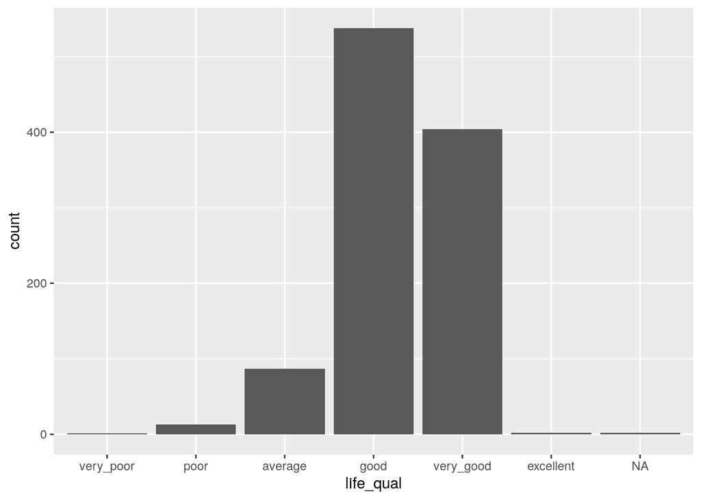

```r
ggplot(additionalq) + geom_bar(aes(x=life_qual))
```

Could excellent be combined very_good and very_poor and poor to average?

```r
additionalq <- additionalq %>% mutate(life_qual = case_when(
  life_qual == "very_poor" ~ "average",
  life_qual == "poor" ~ "average",
  life_qual == "average" ~ "average",
  life_qual == "good" ~ "good",
  life_qual == "very_good" ~ "very_good",
  life_qual == "excellent" ~ "very_good"
)) %>% mutate(life_qual = factor(life_qual))
```

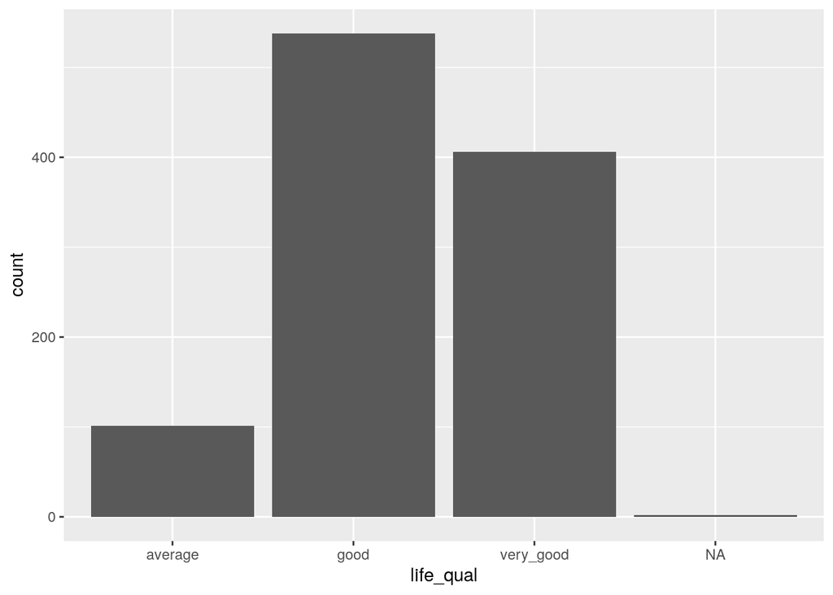

```r
ggplot(additionalq) + geom_bar(aes(x=life_qual))
```

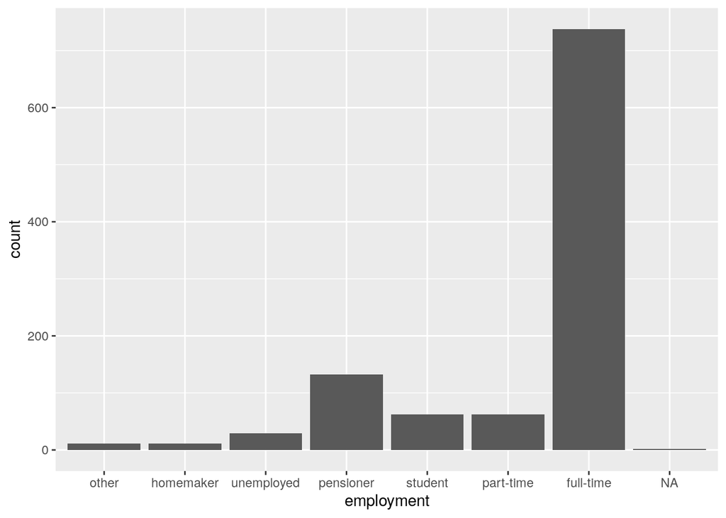

```r
ggplot(additionalq) + geom_bar(aes(x=employment))
```

This is not at all informative. Could it be fulltime or not?

```r
additionalq <- additionalq %>% mutate(employment = case_when(
  employment == "full-time" ~ TRUE,
  TRUE ~ FALSE
  ))
```

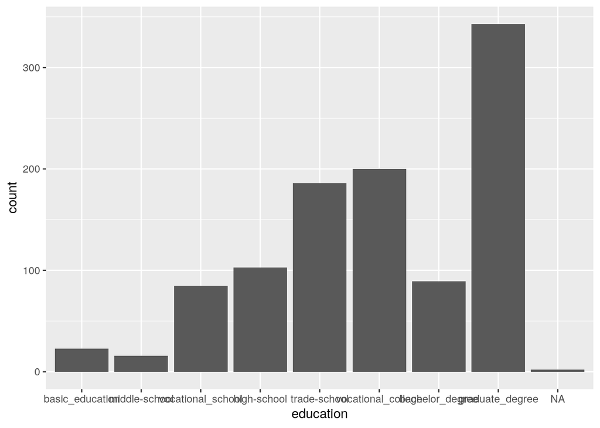

```r
ggplot(additionalq) + geom_bar(aes(x=education))
```

Also some grouping would be good in here.

```r
additionalq <- additionalq %>% mutate(education = case_when(
  education == "trade-school" |  education == "vocational_college" |  education == "graduate_degree" | education == "bachelor_degree"   ~ "high",
  education == "vocational_school" |  education == "high-school"  ~ "middle",
  education == "basic_education" | education == "middle-school"  ~ "lower"

  )) %>% mutate(education = factor(education))
#Later in explorative_analysis.Rmd we find out that education cannot be fitted
additionalq <- additionalq %>% select(-education)
```

```r
cat("Down to:" ,nrow(na.omit(additionalq)),"from:",nrow(additionalq),"\n")
```

```
## Down to: 1045 from: 1047
```

```r
changedata <- na.omit(additionalq)


#changedata <- inner_join(changedata,additionalq,by=c("donor"="donor"))
file <- "../results/changedata.rdata"
save(changedata,file=file)
```

Just to check:

```r
changedata %>% count()
```

```
## # A tibble: 1 x 1
##       n
##   <int>
## 1  1045
```

By dropping many questions we manage to save several hundred donors. Hence, dropping related variables is required. In addition, next in explorative_analysis.Rmd even couple more further variables need to dropped out in order to fit the models.